# ENV221 L12

Author

Peng Zhao

# 1 Overview of the module and R

# 2 R Basic Operations

# 3 R Programming

# 4 Statistical Graphs

# 5 Basic Concepts

# 6 Descriptive statistics

# 7 Distributions and the Central Limit Theorem

# 8 Hypothesis test

# 9 t-test

# 10 Numerical vs. Numerical

# 11 Numerical vs. Categorical

# 12 Categorical vs. Categorical

## 12.1 Learning objectives

In this lecture, you will

1. understand $\chi^2$ test,
2. use $\chi^2$ test in scientific research.

## 12.2 Revisit the frequency table

Example: GAD

A scientist measures the frequency of occurrence of antibodies to the enzyme glutamic acid decarboxylase (GAD) in the plasma of normal control subjects and of subjects with the autoimmune disease stiff-man syndrome. A total of 550 subjects are tested. The results are shown below. Is the occurrence of GAD antibodies associated with the occurrence of stiff-man syndrome?

```r
gad <- read.csv("data/gad.csv")
tb_gad <- table(gad$status, gad$antibody)
```

| id | antibody | status |
| --- | --- | --- |
| 1 | negative | sm |
| 2 | negative | sm |
| 3 | negative | sm |
| 4 | negative | sm |
| 5 | positive | sm |
| 6 | negative | sm |
| 7 | positive | sm |
| 8 | positive | sm |
| 9 | positive | sm |
| 10 | negative | normal |

[output cut: 540 more lines]

```r
tb_gad <- table(gad$status, gad$antibody)
```

|  | negative | positive |
| --- | --- | --- |
| normal | 125 | 55 |
| sm | 150 | 220 |

Transform it into a long table:

```r
df_gad <- data.frame(tb_gad)
```

| Var1 | Var2 | Freq |
| --- | --- | --- |
| normal | negative | 125 |
| sm | negative | 150 |
| normal | positive | 55 |
| sm | positive | 220 |

## 12.3 $\chi^2$ test

### 12.3.1 $\chi^2$ Distribution

PDF:

$$f(x)=\frac{x^{(df / 2)-1} e^{-(x / 2)}}{\left(\frac{df}{2}-1\right) ! 2^{df / 2}}$$

$$df = (r − 1) ( c −1)$$

**$r$:**

Row number

**$c$:**

Column number

A graph:

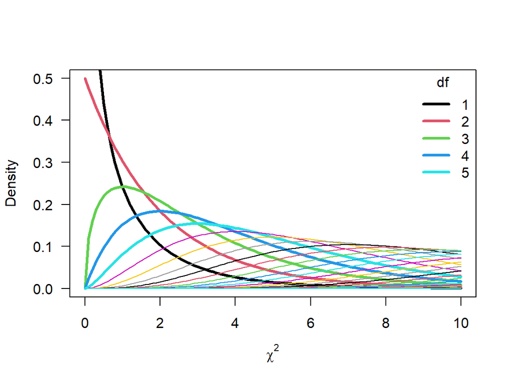

```r
df <- c(1:30, 4:10 * 10)
x_lim <- c(0, 10)
y_lim <- c(0, 0.5)
curve(dchisq(x, df = 1), ylab = "Density", xlab = expression(chi^2),
      xlim = x_lim, ylim = y_lim, lwd = 3,
      col = 1, las = 1)
for (i in 2: length(df)) {
  curve(dchisq(x, df = df[i]), col = i, add = TRUE,
        lwd = c(rep(3, 5), rep(1, length(df - 5)))[i])
}
legend("topright", lty = 1, col = 1:5, legend = 1:5, bty = "n", lwd = 3, title = 'df')
```

Properties:

- A family of curves.
- Mean = $df$.
- variance = $2 df$.

|  | 0.995 | 0.99 | 0.975 | 0.95 | 0.9 | 0.1 | 0.05 | 0.025 | 0.01 | 0.005 |
| --- | --- | --- | --- | --- | --- | --- | --- | --- | --- | --- |
| 1 | 4e-05 | 0.00016 | 0.00098 | 0.00393 | 0.01579 | 2.70554 | 3.84146 | 5.02389 | 6.6349 | 7.87944 |
| 2 | 0.01003 | 0.0201 | 0.05064 | 0.10259 | 0.21072 | 4.60517 | 5.99146 | 7.37776 | 9.21034 | 10.59663 |
| 3 | 0.07172 | 0.11483 | 0.2158 | 0.35185 | 0.58437 | 6.25139 | 7.81473 | 9.3484 | 11.34487 | 12.83816 |
| 4 | 0.20699 | 0.29711 | 0.48442 | 0.71072 | 1.06362 | 7.77944 | 9.48773 | 11.14329 | 13.2767 | 14.86026 |
| 5 | 0.41174 | 0.5543 | 0.83121 | 1.14548 | 1.61031 | 9.23636 | 11.0705 | 12.8325 | 15.08627 | 16.7496 |
| 6 | 0.67573 | 0.87209 | 1.23734 | 1.63538 | 2.20413 | 10.64464 | 12.59159 | 14.44938 | 16.81189 | 18.54758 |
| 7 | 0.98926 | 1.23904 | 1.68987 | 2.16735 | 2.83311 | 12.01704 | 14.06714 | 16.01276 | 18.47531 | 20.27774 |
| 8 | 1.34441 | 1.6465 | 2.17973 | 2.73264 | 3.48954 | 13.36157 | 15.50731 | 17.53455 | 20.09024 | 21.95495 |
| 9 | 1.73493 | 2.0879 | 2.70039 | 3.32511 | 4.16816 | 14.68366 | 16.91898 | 19.02277 | 21.66599 | 23.58935 |
| 10 | 2.15586 | 2.55821 | 3.24697 | 3.9403 | 4.86518 | 15.98718 | 18.30704 | 20.48318 | 23.20925 | 25.18818 |

[output cut: 27 more lines]

```r
chi_sq_score <- qchisq(p = 0.05, df = 2, lower.tail = FALSE)
chi_sq_score
```

```
[1] 5.9915
```

```r
pchisq(q = chi_sq_score, df = 2, lower.tail = FALSE)
```

```
[1] 0.05
```

### 12.3.2 One-category $\chi^2$ test

$$\chi^{2}=\sum\left[\frac{\left(O_{i}-E_{i}\right)^{2}}{E_{i}}\right]$$

**O:**

Observations.

**E:**

Expectations.

*Demo: Mendelian inheritance*

A biologist counted the number of red-, white- and pink-flowered plants resulting after cross-pollination of white and red sweet peas. Mendelian inheritance of this trait predicts that the ratio of red to white to pink should be 1:1:2. The biologist’s results are as follows:

- Red: 72 plants
- White: 63 plants
- Pink: 125 plants

Do the experimental results support this mode of inheritance?

1. Hypotheses and question:
- $H_0$: The ratio of red to white to pink is 1:1:2 (The experiment results follow the theoretical prediction).
- $H_1$: The ratio of red to white to pink is not 1:1:2 (The experiment results do not follow the theoretical prediction).
- Question: Reject $H_0$? Given $\alpha$.
2. Collect data.

```r
dtf <- data.frame(colour = c("red", "white", "pink"),
                  observed = c(72, 63, 125))
sum(dtf$observed)
```

```
[1] 260
```

```r
dtf$expected <- sum(dtf$observed) * c(1, 1, 2) / 4
```

*Action*: Fill in the following table.

| colour | observed | expected | O - E | O - E square |
| --- | --- | --- | --- | --- |
| red | 72 | 65 |  |  |
| white | 63 | 65 |  |  |
| pink | 125 | 130 |  |  |

**Click to see the results**

| colour | observed | expected | O - E | O - E square |
| --- | --- | --- | --- | --- |
| red | 72 | 65 | 7 | 49 |
| white | 63 | 65 | -2 | 4 |
| pink | 125 | 130 | -5 | 25 |

3. Calculate a test statistic: $\chi ^2$

**Click to see the results**

```r
(chi_sq_score <- sum(dtf$`O - E square` / dtf$expected))
```

```
[1] 1.0077
```

```r
(df <- nrow(dtf) - 1)
```

```
[1] 2
```

```r
qchisq(0.05, df, lower.tail = FALSE)
```

```
[1] 5.9915
```

```r
pchisq(chi_sq_score, df, lower.tail = FALSE)
```

```
[1] 0.6042
```

4. Decision.

As $\chi ^2 _\mathrm{score} \le \chi ^2_\mathrm{critical}$, we cannot reject $H_0$.

5. Conclusion.

### 12.3.3 Multiple-category $\chi ^2$ test

When the data contain two or more samples or multiple categories, the data are arranged in contingency tables, and a $\chi ^2$ test can be used to test for association between the variables.

$$E = \frac{\sum _ \mathrm{row}}{\sum _ \mathrm{grand}} \times \frac{\sum _ \mathrm{column}}{\sum _ \mathrm{grand}} \times \sum_\mathrm{grand}=\frac{\sum _ \mathrm{row} \times \sum _ \mathrm{column}}{\sum _ \mathrm{grand}}$$

Example: GAD

A scientist measures the frequency of occurrence of antibodies to the enzyme glutamic acid decarboxylase (GAD) in the plasma of normal control subjects and of subjects with the autoimmune disease stiff-man syndrome. Is the occurrence of GAD antibodies associated with the occurrence of stiff-man syndrome?

1. Hypotheses and question:
- $H_0$: No association between the occurrence of GAD antibodies and the occurrence of stiff-man syndrome.
- $H_1$: Association between the occurrence of GAD antibodies and the occurrence of stiff-man syndrome.
- Question: Reject $H_0$? Given $\alpha$.
2. Collect data.
3. Calculate a test statistic.

*Action*: Fill in the following tables and calculate $\chi ^2$.

|  | observed negative | observed positive | sum |
| --- | --- | --- | --- |
| normal |  |  |  |
| sm syndrom |  |  |  |
| sum |  |  |  |

|  | expected negative | expected positive |
| --- | --- | --- |
| normal |  |  |
| sm syndrom |  |  |

**Click to see the results**

```r
(tb_gad <- table(gad$status, gad$antibody))
tb_gad2 <- matrix(nrow = 2, ncol = 2)
tb_gad2[1, 1] <- sum(tb_gad[1, ]) / sum(tb_gad) * sum(tb_gad[, 1])
tb_gad2[1, 2] <- sum(tb_gad[1, ]) / sum(tb_gad) * sum(tb_gad[, 2])
tb_gad2[2, 1] <- sum(tb_gad[2, ]) / sum(tb_gad) * sum(tb_gad[, 1])
tb_gad2[2, 2] <- sum(tb_gad[2, ]) / sum(tb_gad) * sum(tb_gad[, 2])
tb_gad2
(chi_sq <- sum((tb_gad2 - tb_gad) ^ 2 / tb_gad2))

sqrt(chi_sq / (sum(tb_gad) * (min(dim(tb_gad)) - 1))) # Cramer's coefficient
```

[output not shown]

One-step:

```r
chisq.test(tb_gad)
chit <- chisq.test(tb_gad)
str(chit)
chit$statistic
```

[output not shown]

Why different?

### 12.3.4 Yates’ correction

For small samples ($2\times2$ contingency table):

$$\chi^{2}=\sum\frac{(|O_{i}-E_{i}| - 0.5)^{2}}{E_{i}}$$

```r
(chi_sq2 <- sum((abs(tb_gad2 - tb_gad) - 0.5) ^ 2 / tb_gad2))
```

```
[1] 39.318
```

```r
pchisq(chi_sq2, 1, lower.tail = FALSE)
```

```
[1] 3.6019e-10
```

4. Decision.

For $df = (2 -1)\times(2-1) = 1$, in the $\chi^2$ table, the critical value of $\chi^2 (\alpha=0.05, df=1) = 3.841$, which is much smaller than our calculated $\chi^2$. Thus, we reject $H_0$.

5. Conclusion.

There is a significant association between the occurrence of GAD antibodies and the occurrence of stiff-man syndrome.

## 12.4 Readings

- *Elementary Statistics*, Chapter 10.1 and 10.2

## 12.5 Highlights

- Carry out a step-by-step $\chi^2$-test for a scientific question.
  - State $H_0$ and $H_1$.
  - Calculate the critical value for a given $\alpha$.
  - Calculate the testing statistics ($\chi^2$ score).
  - Draw a conclusion for the scientific question.